# 2.Statistical Modeling

## Content of the second chapter

- Explain difference between “Probability” and “Statistics”
- Fit data to probability distributions
- First encounter with the maximum likelihood method through a simulation experiement
- Make inferences from data for which we have prior information using the Bayesian paradigm
- Use statistical models and estimation to evaluate dependencies in binomial and multinomial distributions
- Analyse some historically interesting genomic data assembled into tables
- Make Markov chain models for dependent data
- Do a few concrete applications related to genomes

## The difference between statistical and probabilistic models

- A probabilistic analysis is possible when we know the model for the randomness in the data, *and* the parameters’ actual values.
- But when we only have the observed data and we need to estimate both a probability model and eventually the missing parameter(s) for that model, we need to work with statistical inference

## A simple example of statistical modeling (Poisson distribution)

- Start with the data

```
load("../data/e100.RData")
```

- Estimating the parameter of the Poisson distribution

```
table(e100)
```

```
## e100
##  0  1  2  7
## 58 34  7  1
```

Let the value of the Poisson parameter be m. Since we suppose the data derive from independent draws, this probability is simply the product of individual probabilities:

$Pr(58 * 0, 34 * 1, 7 * 2, 1 * 7| \text{data are Poisson(m)}) = Pr(0)^{58} * Pr(1)^{34} * Pr(2)^7 * Pr(7)^1$

This probability is the **likelihood function** of $\lambda$ and we write it:

$L(\lambda, x = (k_1, k_2,...,k_n)) = \prod_{i=1}^{n}f(k_i)$

Computational illustration:

```
loglikelihood  =  function(lambda, data = e100) {
  sum(log(dpois(data, lambda)))
}
```

```
lambdas = seq(0.05, 0.95, length = 100)
loglik = vapply(lambdas, loglikelihood, numeric(1))
plot(lambdas, loglik, type = "l", col = "red", ylab = "", lwd = 2,
     xlab = expression(lambda))
m0 = mean(e100)
abline(v = m0, col = "blue", lwd = 2)
abline(h = loglikelihood(m0), col = "purple", lwd = 2)
m0
```

```
## [1] 0.55
```

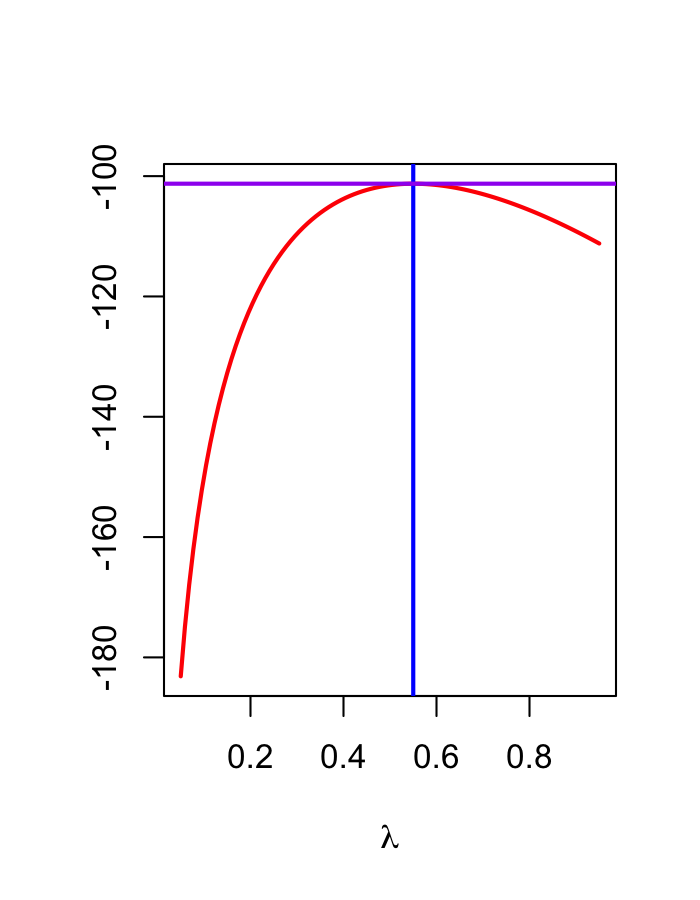

\

The red curve is the log-likelihood function. The vertical line shows the value of m (the mean) and the horizontal line the log-likelihood of m. It looks like m maximizes the likelihood.

```
gf  =  goodfit(e100, "poisson")
gf$par
```

```
## $lambda
## [1] 0.55
```

## Binomial distributions and maximum likelihood

- Example

Suppose we take a sample of n = 120 males and test them for red-green colorblindness. We can code the data as 0 if the subject is not colorblind and 1 if he is. We summarize the data by the table:

```
table(cb)
```

```
## cb
##   0   1
## 110  10
```

Intuitively, we will estimate $\hat{p} = \frac{1}{12}$, which turns out to be the maximum likelihood estimate.

As before in the case of the Poisson, if we compute the likelihood for many possible p, we can plot it and see where its maximum falls.

```
probs  =  seq(0, 0.3, by = 0.005)
likelihood = dbinom(sum(cb), prob = probs, size = length(cb))
plot(probs, likelihood, pch = 16, xlab = "probability of success",
       ylab = "likelihood", cex=0.6)
probs[which.max(likelihood)]
```

```
## [1] 0.085
```

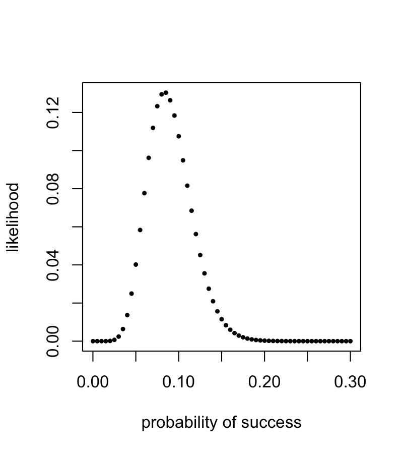

\

- Likelihood for the binomial distribution

$f(\theta|n,y) = f(y|n,\theta) = \binom{n}{y}*\theta^y*(1-\theta)^{(n-y)}$

Here n is the number of trials and y is the number of successes.

### Classical statistics for classical data

Classical statistical testing framework: null model

Goal: test whether there is something more interesting going on by computing the probability that the data are compatible with that model

In other situations, we have two competing models that we can compare, as we will see later.

Another method is regression: determine how a count-based response variable depends on a continuous covariate

## Bayesian Thinking

Difference in comparison to classical approach: prior knowledge

Prior and posterior distributions are used as models of our knowledge before and after collecting some data and making an observation.

Let H be our hypothesis. We write the prior probability as $Pr(H)$ and the posterior probability as $Pr(H|D)$ i.e. the probability of H given that we saw D.

### Example: Haplotype frequencies

Haplotype: a collection of alleles (DNA sequence variants) that are spatially adjacent on a chromosome, are usually inherited together (recombination tends not to disconnect them), and thus are genetically linked

We want to estimate the proportion of a particular haplotype that consists of a set of different short tandem repeats (STR).

```
haplo6=read.table("../data/haplotype6.txt",header = TRUE)
haplo6
```

```
##   Individual DYS19 DXYS156Y DYS389m DYS389n DYS389p
## 1         H1    14       12       4      12       3
## 2         H3    15       13       4      13       3
## 3         H4    15       11       5      11       3
## 4         H5    17       13       4      11       3
## 5         H7    13       12       5      12       3
## 6         H8    16       11       5      12       3
```

### Simulation study of the Bayesian paradigm for the binomial

Now the Bayesian world view allows us to see our parameter $\theta$ as a draw from a statistical distribution. In our situation it is convenient to use the beta distribution:

$f_{\alpha,\beta}(x) = \frac{x^{\alpha-1}(1-x)^{\beta-1}}{B(\alpha,\beta)} \text{ where } B(\alpha,\beta) = \frac{\Gamma(\alpha)\Gamma(\beta)}{\Gamma(\alpha + \beta)}$

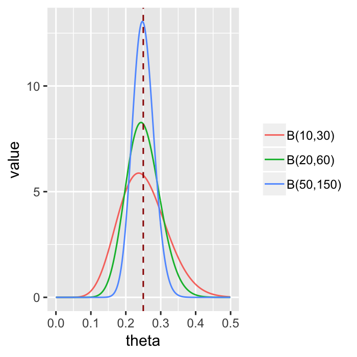

\

The distribution of Y:

For a given choice of $\theta$ we know what the distribution of Y is because of the equation

$f(\theta|n,y) = f(y|n,\theta) = \binom{n}{y}*\theta^y*(1-\theta)^{(n-y)}$

But what is the distribution of Y if $\theta$ itself also varies according to some distribution? We call this the marginal distribution of Y.

Visualisation:

```
rtheta = rbeta(100000, 50, 350)
y = vapply(rtheta, function(th) {
  rbinom(1, prob = th, size = 300)
}, numeric(1))
hist(y, breaks = 50, col = "orange", main = "", xlab = "")
```

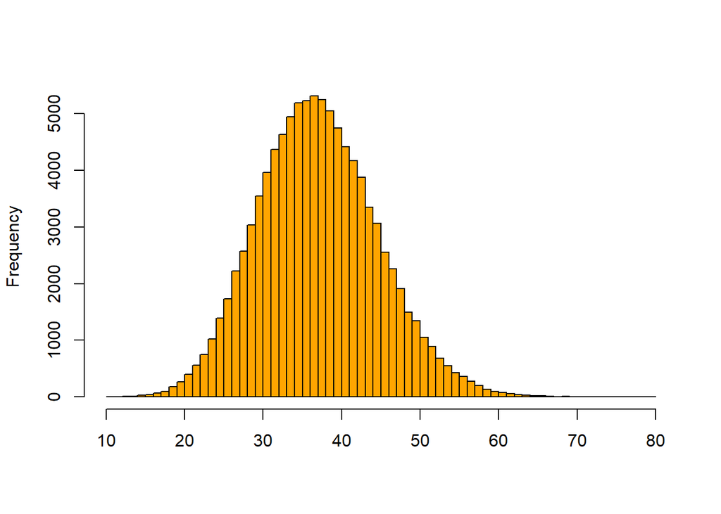

\ Let´s say we have 40 successes out of our 300 trials. Histogram of all the $\theta$s such that Y = 40: the posterior distribution

```
thetaPostEmp = rtheta[ y == 40 ]
hist(thetaPostEmp, breaks = 40, col = "chartreuse4", main = "",
  probability = TRUE, xlab = expression("posterior"~theta))
densPostTheory  =  dbeta(thetas, 90, 610)
lines(thetas, densPostTheory, type="l", lwd = 3)
```

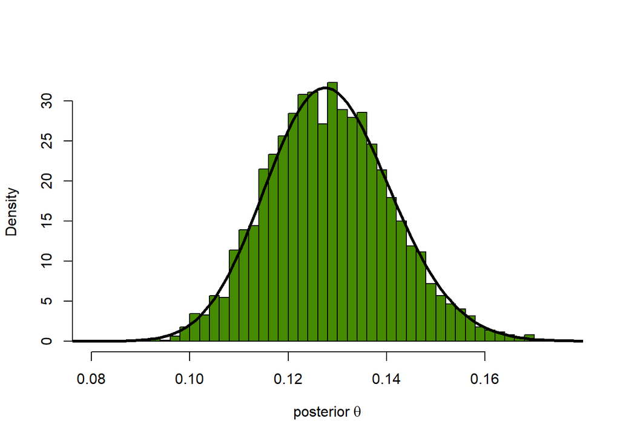

\

We can also check the means of both distributions computed above and see that they are close to 4 significant digits:

```
mean(thetaPostEmp)
```

```
## [1] 0.1285074
```

```
dtheta = thetas[2]-thetas[1]
sum(thetas * densPostTheory * dtheta)
```

```
## [1] 0.1285714
```

Alternative: Monte Carlo integration

```
thetaPostMC = rbeta(n = 1e6, 90, 610)
mean(thetaPostMC)
```

```
## [1] 0.1285704
```

Now we have seen that the posterior distribution is also a beta. In our case its parameters $\alpha$ = 90 and $\beta$ = 610 were obtained by summing the prior parameters $\alpha$ = 50 and $\beta$ = 350 with the observed successes Y = 40 and the observed failures (n - Y) = 260 thus obtaining the posterior $beta(90,610) = beta(\alpha+Y,\beta+(n-Y))$

Now we can take the value that maximizes the posterior distribution as our best estimate for $\theta$:

$\frac{\alpha-1}{\alpha+\beta-2}= \frac{89}{698}=0.128$

- Suppose we had a second series of data

Now we have the prior beta(90,610)

We collect a new set of data with n = 150 observations and Y = 25 successes, thus 125 failures.

Using the same reasoning as before, the new posterior will be: beta(90+25, 610+125) = beta(115,735) The theoretical maximum a posteriori (MAP) estimate would be the mode of beta(115,735), ie $\frac{114}{848} = 0.134$. So we can take this as an estimate for $\theta$

- Confidence Statements for the proportion parameter

Posterior credibility interval: We can take the 2.5 and 97.5-th percentiles of the posterior distribution:

```
quantile(mcPost2, c(0.025, 0.975))
```

```
##      2.5%     97.5%
## 0.1131418 0.1590589
```

So we get values L and U such that $Pr(L \leq \theta \leq U) = 0.95$

### Exercises:

#### Exercise 2.2

*Make a function that generates n random uniform numbers between 0 an 7 and returns their maximum. Execute the function for n = 25. Repeat this procedure B = 100 times. Plot the distribution of these maxima. What is the maximum likelihood estimate of the maximum of a sample of size 25 (call it $\hat{\theta}$)? Can you find a theoretical justification and the true maximum $\theta$?*

#### Exercise 2.6

*Choose your own prior for the parameters of the beta distribution. You can do this by sketching it here: https://jhubiostatistics.shinyapps.io/drawyourprior Once you have set up a prior, re-analyse the data from our example, where we saw Y = 40 successes out of n = 300 trials. Compare your posterior distribution to the one we obtained.*

### Thank you for your attention